# Practical Machine Learning Report

Kong, Seok-kyu

2015-10-25

# Summary

The goal of this project is to predict the manner in which they did the exercise. This is the “classe” variable in the training set. I have fitted two models and compared its accuracy. First model, CART’s accuracy is less than 60%. Second model, its accuracy is about 99% and OOB estimate of error rate is about 0.5%. I think that random forest model is fitted very well.

# Pre-Processing

Loading the training and test dataset from [Human Activity Recognition](http://groupware.les.inf.puc-rio.br/har)

```r
# the url of dataset
url_training <- "https://d396qusza40orc.cloudfront.net/predmachlearn/pml-training.csv"
url_testing <- "https://d396qusza40orc.cloudfront.net/predmachlearn/pml-testing.csv"

# local files
fn_training <- "./data/pml-training.csv"
fn_testing <- "./data/pml-testing.csv"

# create directory of data
if(! file.exists("./data"))
    dir.create("./data")

# loading dataset
if(! file.exists(fn_training))
{
    download.file(url_training, destfile = fn_training, method="curl")
    download.file(url_testing, destfile = fn_testing, method="curl")
}

# specify na strings for selecting effective columns
df_training <- read.csv(fn_training, na.strings = c("", "NA"))
df_testing <- read.csv(fn_testing, na.strings = c("", "NA"))

## Feature Selection
```

Remove columns which have many NA’s. For the general modeling, I removed the user name variable and others depending on personal feature.

```r
library(caret)
library(dplyr)
library(ggplot2)
library(rattle)             # for fancyRpartPlot()
library(randomForest)       # for randomForest()

# ignore the proportion of missing values over than 10%.
count_na <- function (a) {mean(is.na(a))}    # count NA function
df_training2 <- df_training[,sapply(df_training, count_na) < 0.1]    # select columns

# remove columns which depend on personal features
# so, now 53 columns.
df_training2 <- df_training2[,-c(1:7)]

# just memo:
# df_training2 <- df_training2[, ! grepl("(X|user|timestamp|window)", names(df_training2))]

# check to remove Near Zero Var
nsv <- nearZeroVar(df_training2, saveMetrics = TRUE)
```

## Data Splitting

```r
set.seed(32345)     # for repliction experiment
inTrain <- createDataPartition(y=df_training2$classe, p=0.7, list=FALSE)
training <- df_training2[inTrain,]
testing <- df_training2[-inTrain,]
```

Patterns in rows and columns

In general, with matrix data, there may be patterns that occur accross the rows and columns of the matrix. I can display this by looking at the row and column means of the data. It takes a like of histogram.

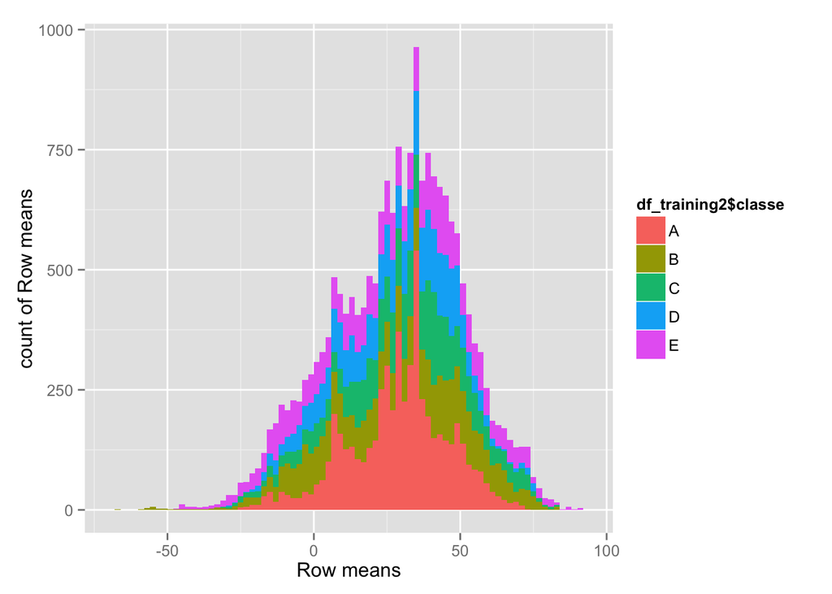

```r
# make histogram of rowmeans by classe
qplot(x=rowMeans(df_training2[, -53]), fill=df_training2$classe, binwidth=2) + labs(x = "Row means", y = "count of Row means")
```

# Fit modeling

I have fitted two models and compare its accuracy.

## using rpart (CART, Classification and Regression Trees)

```r
modFitRpart <- train(classe ~ ., data=training, method="rpart")
modFitRpart
```

```
## CART
##
## 13737 samples
##    52 predictor
##     5 classes: 'A', 'B', 'C', 'D', 'E'
##
## No pre-processing
## Resampling: Bootstrapped (25 reps)
##
## Summary of sample sizes: 13737, 13737, 13737, 13737, 13737, 13737, ...
##
## Resampling results across tuning parameters:
##
##   cp          Accuracy   Kappa       Accuracy SD  Kappa SD
##   0.03590683  0.5189904  0.37560960  0.02260069   0.03409801
##   0.06011596  0.4267976  0.22338634  0.06683803   0.11155533
##   0.11646831  0.3267613  0.06100108  0.04266704   0.06484812
##
## Accuracy was used to select the optimal model using  the largest value.
## The final value used for the model was cp = 0.03590683.
```

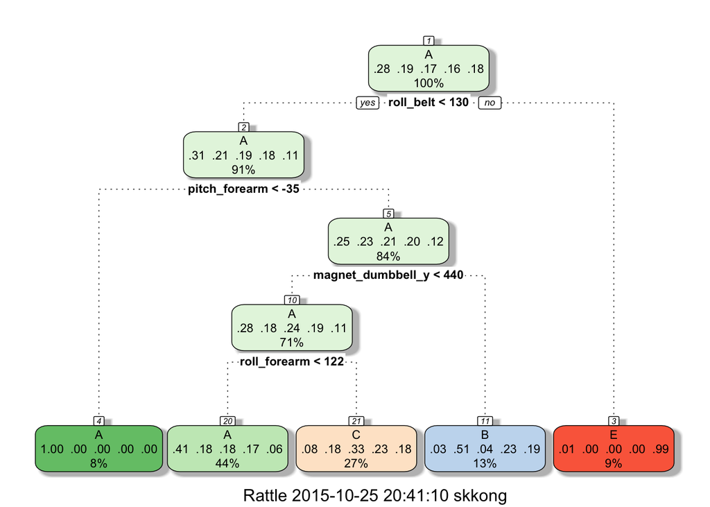

```r
fancyRpartPlot(modFitRpart$finalModel)
```

```r
pred_rpart <- predict(modFitRpart, newdata=testing)
resultRpart <- confusionMatrix(pred_rpart, testing$classe)
resultRpart$overall[1]
```

```
##  Accuracy
## 0.4915888
```

It is 0.4915888 accuracy. Its accuracy is less than 60% and is not so good model.

## Using random forest

```r
# modFit <- train(classe ~ ., data=training, method="rf", prox=TRUE)    # too slow
modFitRf <- randomForest(classe ~ ., data=training, importance=TRUE)    # for evaluating variable importance
modFitRf
```

```
##
## Call:
##  randomForest(formula = classe ~ ., data = training, importance = TRUE)
##                Type of random forest: classification
##                      Number of trees: 500
## No. of variables tried at each split: 7
##
##         OOB estimate of  error rate: 0.49%
## Confusion matrix:
##      A    B    C    D    E  class.error
## A 3903    3    0    0    0 0.0007680492
## B   12 2641    5    0    0 0.0063957863
## C    0   16 2379    1    0 0.0070951586
## D    0    0   22 2227    3 0.0111012433
## E    0    0    0    5 2520 0.0019801980
```

```r
#getTree(modFitRf, k=2)
```

```r
pred_rf <- predict(modFitRf, newdata=testing)
resultRf <- confusionMatrix(pred_rf, testing$classe)
table(pred_rf, testing$classe)
```

```
##
## pred_rf    A    B    C    D    E
##       A 1673    8    0    0    0
##       B    1 1128    6    0    0
##       C    0    3 1017   11    0
##       D    0    0    3  952    0
##       E    0    0    0    1 1082
```

```r
head(importance(modFitRf), 5)
```

```
##                         A        B        C        D        E
## roll_belt        36.88635 45.24159 43.17527 42.53199 40.43365
## pitch_belt       30.38217 52.49599 37.71660 34.77822 30.49856
## yaw_belt         47.05255 43.74127 42.06239 45.41459 32.90973
## total_accel_belt 14.18500 17.88563 14.68345 15.59806 15.99397
## gyros_belt_x     17.64698 17.16530 19.49397 14.28828 16.53568
##                  MeanDecreaseAccuracy MeanDecreaseGini
## roll_belt                    51.81997        874.21016
## pitch_belt                   50.32307        482.76845
## yaw_belt                     62.17722        635.74552
## total_accel_belt             18.12307        156.53797
## gyros_belt_x                 24.53094         68.42282
```

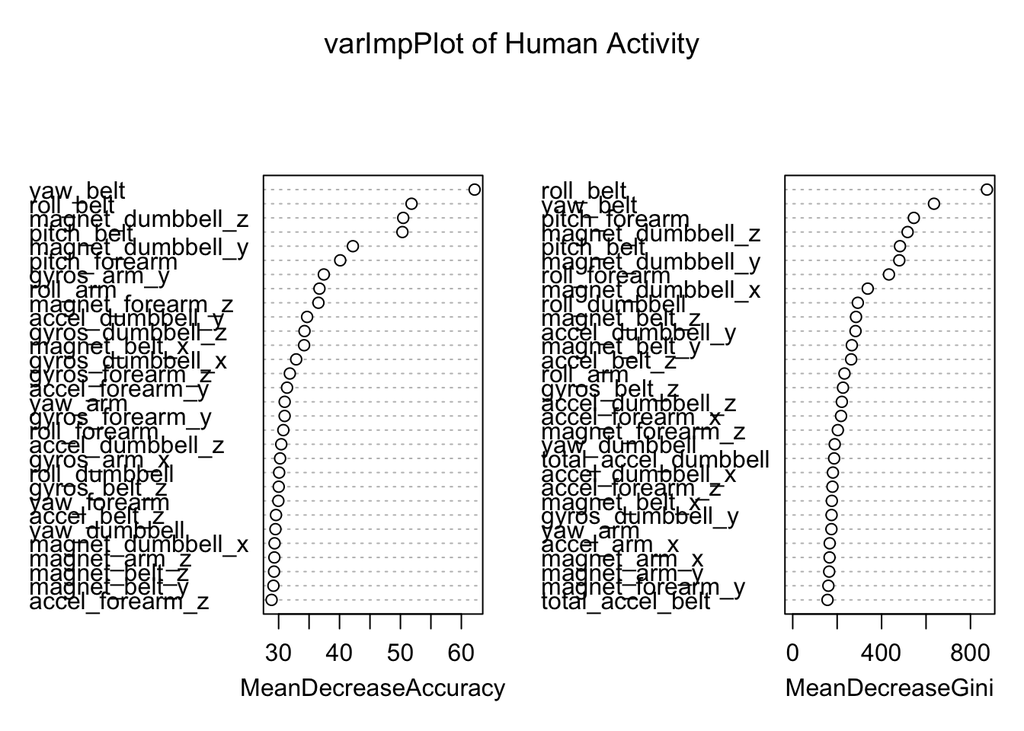

```r
varImpPlot(modFitRf, main="varImpPlot of Human Activity")
```

OOB estimatate of error rate is about 0.5% in random forest model. When I predict testing data set, it is 0.9943925 accuracy. Accuracy is over than 99%. I think that it is very good model.